# Project Stage 2

## 5.2 10-fold Cross Validation

```r
Lass.cv <- cv.gamlr(trainx, as.factor(trainy), verb = TRUE, nfold = 10)
```

```
## fold 1,2,3,4,5,6,7,8,9,10,done.
```

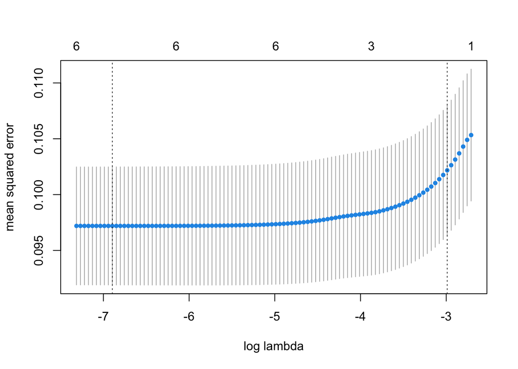

```r
plot(Lass.cv)
```

## 5.3 Alternative Models with Different Methods

### 5.3.1 Support Vector Machines

```r
set.seed(5)

support <- svm(Result ~ ., data = train_var)

support
```

```
##
## Call:
## svm(formula = Result ~ ., data = train_var)
##
##
## Parameters:
##    SVM-Type:  C-classification
##  SVM-Kernel:  radial
##        cost:  1
##
## Number of Support Vectors:  429
```

```r
sup_predict <- predict(support, na.omit(train_val))

sup_perform <- table(na.omit(train_val)$Result, sup_predict, dnn = c("Actual", "Predicted"))

sup_perform
```

```
##           Predicted
## Actual     Approved Denied
##   Approved      593     18
##   Denied         35     57
```

#### 5.3.1.1 Performance of Support Vector Machines

```r
performance(sup_perform)
```

```
## Sensitivity = 0.6196
## Specificity = 0.9705
## Positive Predictive Value = 0.76
## Negative Predictive Value = 0.9705
## Accuracy = 0.9246
```

### 5.3.2 Decision Tree

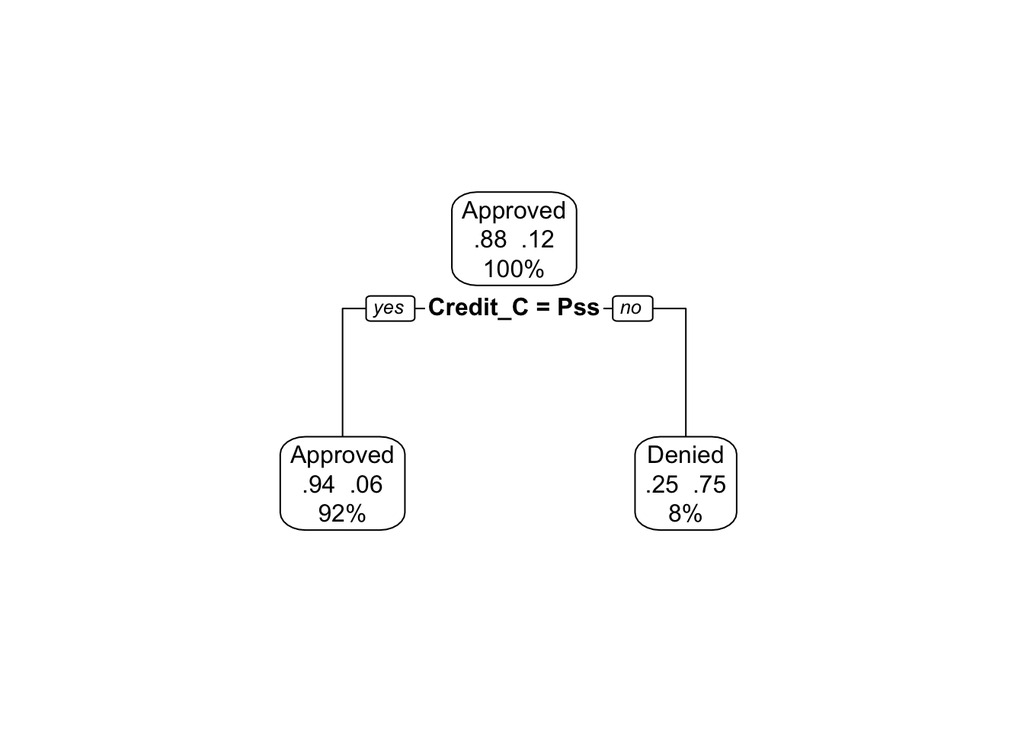

```r
set.seed(5)

Tree <- rpart(Result ~ ., data = train_var, method = 'class', parms = list(split = 'information'))

prp(Tree, type = 2, extra = 104, fallen.leaves = T)
```

```r
tree_predict <- predict(Tree, train_var, type = "class")
tree_perform <- table(train_var$Result, tree_predict, dnn = c("Actual", "Predicted"))

tree_perform
```

```
##           Predicted
## Actual     Approved Denied
##   Approved     1422     32
##   Denied         93     96
```

#### 5.3.2.1 Performance of Decision Trees

```r
performance(tree_perform)
```

```
## Sensitivity = 0.5079
## Specificity = 0.978
## Positive Predictive Value = 0.75
## Negative Predictive Value = 0.978
## Accuracy = 0.9239
```

### 5.3.3 Random Forests

```r
set.seed(5)

fit.forest <- randomForest(Result ~ ., data = train_var, na.action = na.roughfix, importance = TRUE)

fit.forest
```

```
##
## Call:
##  randomForest(formula = Result ~ ., data = train_var, importance = TRUE,      na.action = na.roughfix)
##                Type of random forest: classification
##                      Number of trees: 500
## No. of variables tried at each split: 3
##
##         OOB estimate of  error rate: 8.46%
## Confusion matrix:
##          Approved Denied class.error
## Approved     1415     39  0.02682256
## Denied        100     89  0.52910053
```

```r
forest_predict <- predict(fit.forest, train_val, type = "response")
forest_perform <- table(train_val$Result, forest_predict, dnn = c("Actual", "Predicted"))

forest_perform
```

```
##           Predicted
## Actual     Approved Denied
##   Approved      588     23
##   Denied         33     59
```

#### 5.3.3.1 Performance of Random Forests

```r
performance(forest_perform)
```

```
## Sensitivity = 0.6413
## Specificity = 0.9624
## Positive Predictive Value = 0.7195
## Negative Predictive Value = 0.9624
## Accuracy = 0.9203
```

### 5.3.4 Conditional Trees

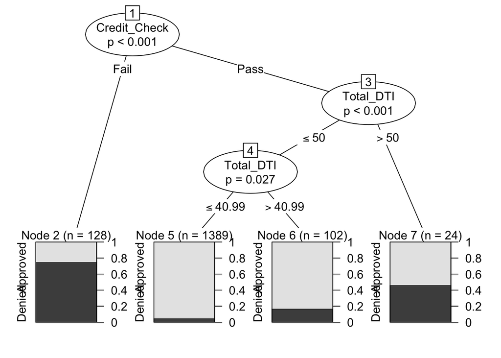

```r
set.seed(5)

fit.ctree <- ctree(Result ~ ., data = train_var)

plot(fit.ctree)
```

```r
ctree_predict <- predict(fit.ctree, train_var, type = "response")
ctree_perform <- table(train_var$Result, ctree_predict, dnn = c("Actual", "Predicted"))

ctree_perform
```

```
##           Predicted
## Actual     Approved Denied
##   Approved     1422     32
##   Denied         93     96
```

#### 5.3.4.1 Performance of Conditional Trees

```r
performance(ctree_perform)
```

```
## Sensitivity = 0.5079
## Specificity = 0.978
## Positive Predictive Value = 0.75
## Negative Predictive Value = 0.978
## Accuracy = 0.9239
```

# 6 Identifying Superior Model with New Estimates (E)

Of the competing models that you estimated and thresholds that you evaluated, identify the superior model for classification purposes. Re-estimate the model with the full sample of data. Then, graph the ROC, calculate the AUC, and compute the confusion matrix at the threshold level associated with the minimum average test mis-classification rate . Calculate the classifier sensitivity and specificity, the false-positive rate, the false negative rate, the accuracy, and overall mis-classification rate. How well does your superior model perform relative to the model estimated in C? Explain. Note that to do so you will need to calculate the confusion matrix from the estimated model in C at the threshold level.

## 6.1 Picking the Superior Model

Based on the performance of each model in the last part, the support vector machines has the greatest accuracy calculation at 92.46%. This will be the superior model for classification purposes to find new threshold